# Consequences of Covid-19 for Candle Critiques

Khoa Nguyen

3/22/2021

For this assignment, you will produce a report exploring the impact of Covid-19 on scented candle ratings.

Write this assignment like a report. You should describe the dataset, show appropriate plots, and interpret them. Remove the instruction text from this document.

In your report, fold the code blocks, enable code highlighting, and set an HTML theme of your choice. Set other document options as you prefer and as appropriate.

## The data

You will work with two datasets `Scented_all.xlsx` and `Unscented_all.xlsx`. Each dataset contains the following information for the Top 3 selling scented or unscented candles sold on Amazon:

1. `CandleID`: A numeric id variable for candle 1-3 in each category.
2. `Date`: The date of the review.
3. `Rating`: The 1-5 rating for the review.
4. `Review`: For the scented candles, the text of the review.

```r
Scented_Data <- read_excel(here::here("HW5", "Scented_all.xlsx"))
Unscented_Data <- read_excel(here::here("hw5", "Unscented_all.xlsx"))
```

## Part 1: Average daily ratings for scented and unscented candles

For each category of candle (scented versus unscented), for all days from **2017-01-01** onward, create a plot showing:

1. Date on the x axis 1. Hint: use `scale_x_date()` 2. Format the date labels as `"%m-%Y"` 3. Set the date breaks to be “6 months”
2. **Average daily rating** of each candle on the y axis
3. A smooth trend line (not linear; `method = "loess"`)
4. A dashed vertical line at January 01, 2020 1. Hint: use `geom_vline()` and set `xintercept = as.numeric(as.Date("2020-01-20"))`

Be sure to make the plots beautiful.

1. Address overplotting of points using transparency or shapes.
2. Use an appealing theme and color scheme.
3. Set appropriately formatted axis titles and main plot title.
4. Place the two plots side by side.

Note: The raw data are **individual reviews** so you will need to compute summary results to get average daily ratings for the desired date range.

Interpret these graphs. What do they show about scented candles over the time period?

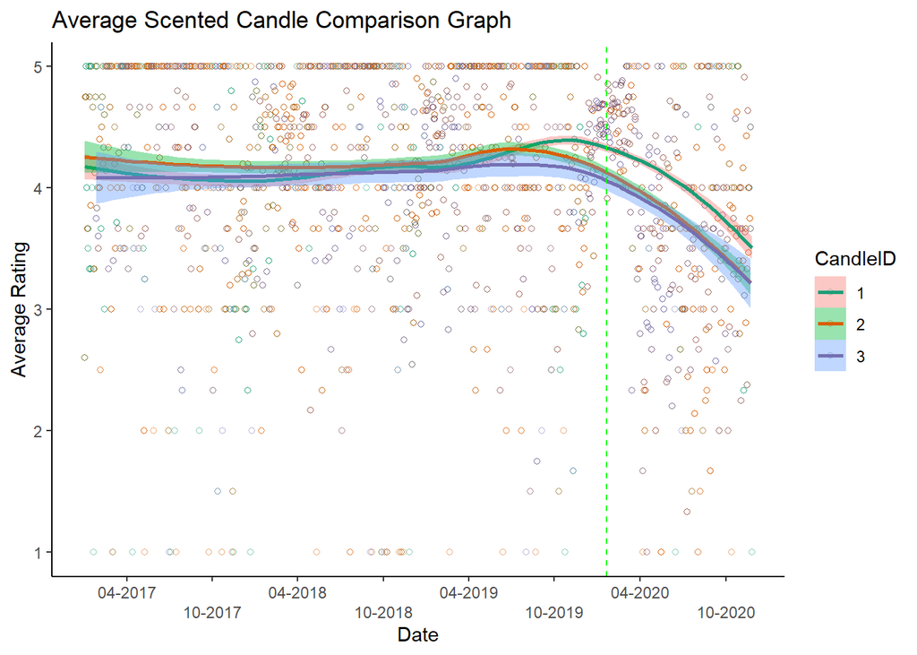

```r
Adjusted_Scented_Data <- Scented_Data %>%
  mutate(CandleID = as.factor(CandleID),
         Date = as.Date(Date))

Plot_Adj_Scent_Data <- Adjusted_Scented_Data %>%
  filter(Date > "2017-01-01") %>%
  group_by(Date) %>%
  mutate(
    mean_rate = mean(Rating)
  ) %>%
  ggplot(
    aes(x = Date,
        y = mean_rate,
        shape = CandleID,
        color = CandleID,
        fill = CandleID
        )
    ) +
  geom_point(
    alpha = .5,
    shape = 1) +
  scale_x_date(
    name = "Date",
               date_breaks = "6 months",
               date_labels = "%m-%Y"
    ) +
  geom_smooth(
    method = "loess"
    ) +
  geom_vline(
    xintercept = as.numeric(
      as.Date(
        "2020-01-20")),
    linetype = "dashed",
    color = "green") +
  scale_y_continuous(
    name = "Average Rating") +
  theme_classic() +
  ggtitle("Average Scented Candle Comparison Graph") +
  guides(
    x = guide_axis(
      n.dodge = 2)) +
  scale_color_brewer(
    palette = "Dark2")

Plot_Adj_Scent_Data
```

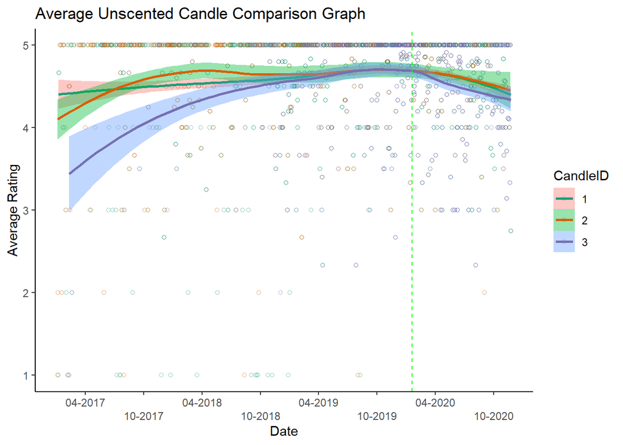

```r
Adjusted_Unscented_Data <- Unscented_Data %>%
  mutate(
    CandleID = as.factor(CandleID),
         Date = as.Date(Date))

Plot_Adj_Unscent_Data <- Adjusted_Unscented_Data %>%
  filter(Date > "2017-01-01") %>%
  group_by(Date) %>%
  mutate(
    mean_rate = mean(Rating)
  ) %>%
  ggplot(
    aes(x = Date,
        y = mean_rate,
        shape = CandleID,
        color = CandleID,
        fill = CandleID
        )
    ) +
  geom_point(
    alpha = .5,
    shape = 1) +
  scale_x_date(
    name = "Date",
               date_breaks = "6 months",
               date_labels = "%m-%Y"
    ) +
  geom_smooth(
    method = "loess"
    ) +
  geom_vline(
    xintercept = as.numeric(
      as.Date(
        "2020-01-20")),
    linetype = "dashed",
    color = "green") +
  scale_y_continuous(
    name = "Average Rating") +
  theme_classic() +
  ggtitle("Average Unscented Candle Comparison Graph") +
  guides(
    x = guide_axis(
      n.dodge = 2)) +
  scale_color_brewer(
    palette = "Dark2")

Plot_Adj_Unscent_Data
```

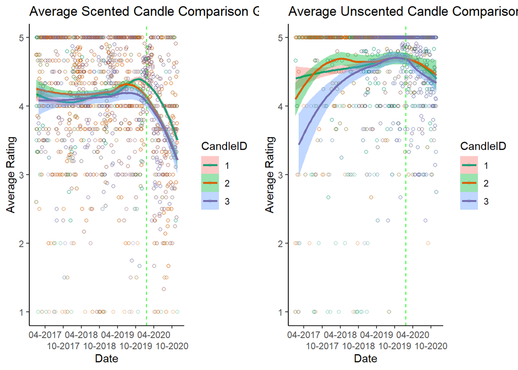

```r
grid.arrange(Plot_Adj_Scent_Data, Plot_Adj_Unscent_Data, ncol = 2)
```

## Part 2: Combined plot

Combine the two datasets into one and make a plot similar to above, but showing both unscented and scented candles. Distinguish scented versus unscented candles using color, shape, and line type (for the trend lines).

```r
candles_full <- bind_rows(
    scented = Adjusted_Scented_Data,
    unscented = Adjusted_Unscented_Data,
    .id = "Scented"
)
```

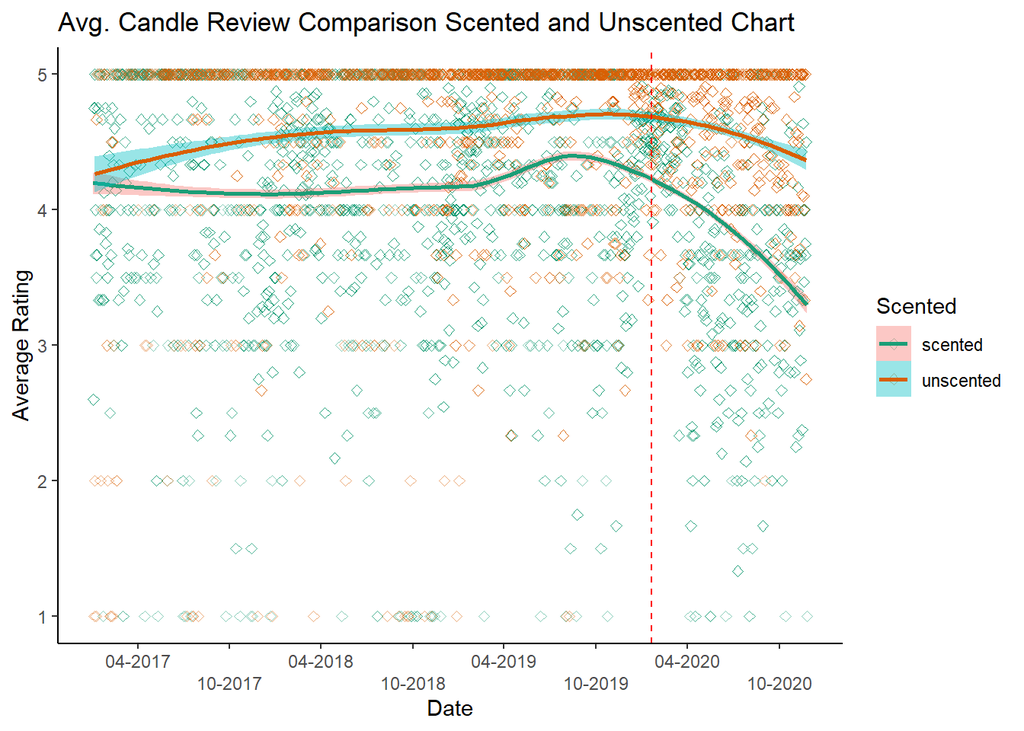

```r
New_plot <- candles_full %>%
  filter(Date > "2017-01-01") %>%
  group_by(Date, Scented) %>%
  mutate(mean_rat_comb = mean(Rating)) %>%
  ggplot(
    aes(x = Date,
        y = mean_rat_comb,
        shape = Scented,
        color = Scented,
        fill = Scented
  )) +
  geom_point(alpha = .5,
             shape = 5,
             ) +
  scale_x_date(
    name = "Date",
    date_breaks = "6 months",
    date_labels = "%m-%Y") +
  geom_smooth(method = "loess") +
  geom_vline(xintercept = as.numeric(
    as.Date("2020-01-20")),
    linetype = "dashed",
    color = "red") +
  scale_y_continuous(
    name = "Average Rating") +
  theme_classic() +
  ggtitle("Avg. Candle Review Comparison Scented and Unscented Chart") +
  guides(
    x = guide_axis(
      n.dodge = 2)) +
  scale_color_brewer(
    palette = "Dark2")

New_plot
```

Which of these two sets of plots do you find easier to interpret?

> the individual graphs in part 1 seem to be a lot easier to interpret as it is not crowded with information that leads to information overload.But if a comparison is the main purpose here, having the combined graph is actually more useful as we can clearly see the current status of each type of candles and compare them to the others. It is also a lot easier to determine and predict future ratings based on the overlapping ratings for each type of candles on different date leading up to the drop and the post-drop in ratings.

## Part 3: Proportion of reviews mentioning “no scent”

Use the scented candles database and make one more plot showing:

1. For **each month in 2019 and 2020**,
2. On the x axis, month and year
3. On the y axis, the **proportion of reviews** mentioning that the scented candles have no smell - Include both the mean (proportion) and a 95% confidence interval
4. Color the symbols by year (2019 vs 2020)

Hints:

> *I don’t know what I am doing….*

```r
Scented_Data$CodeReview <- str_no_scent(Scented_Data$Review)
Scented_Data$CodeReview_1 <- factor(Scented_Data$CodeReview, labels = c("scent", "noscent"))

print(Scented_Data)
```

```
## # A tibble: 8,614 x 6
##    CandleID Date                Rating Review            CodeReview CodeReview_1
##       <dbl> <dttm>               <dbl> <chr>                  <dbl> <fct>
##  1        1 2018-04-08 00:00:00      5 "I love candles ~          0 scent
##  2        1 2018-11-08 00:00:00      1 "Not up to par. ~          1 noscent
##  3        1 2018-02-01 00:00:00      5 "the Fresh Scent~          0 scent
##  4        1 2018-12-04 00:00:00      1 "Smelled Bad I p~          0 scent
##  5        1 2018-01-18 00:00:00      5 "Favorite Yankee~          0 scent
##  6        1 2018-09-09 00:00:00      5 "Excellent candl~          0 scent
##  7        1 2017-12-29 00:00:00      1 "Not the same ri~          0 scent
##  8        1 2018-08-17 00:00:00      5 "Love Balsam & C~          0 scent
##  9        1 2019-02-25 00:00:00      1 "Its too bad. I ~          0 scent
## 10        1 2019-01-02 00:00:00      1 "A candle must b~          0 scent
## # ... with 8,604 more rows
```

[figure not shown]

```r
What_scent <- Scented_Data %>%
  filter(Date > "2019-01-01") %>%
  mutate(month = lubridate::floor_date(Date, "month")) %>%
  group_by(month, CodeReview_1) %>%
    ggplot(aes(x = month, y = (..count..)/sum(..count..))) +
     geom_bar(position = "dodge") +
  stat_summary(aes(y = CodeReview_1), fun.data = mean_cl_normal)

What_scent
```

What pattern do you see?

Is there a trend over time regarding smell-related reviews?

How does 2020 compare to 2019?

> 2020 seem to have more increase reviews of such issue (I think).